# Lab 1

GitHub link: https://github.com/TylerWolfWilliams/GSB-544

# Titanic Wrangling

In this practice activity you’ll continue to work with the titanic dataset in ways that flex what you’ve learned about both data wrangling and data visualization.

# Import the titanic dataset here

```python
import numpy as np
import pandas as pd
from plotnine import ggplot, aes, geom_tile, scale_fill_gradient, theme_minimal

data_dir = "https://dlsun.github.io/pods/data/"
df_titanic = pd.read_csv(data_dir + "titanic.csv")
```

## 1. Filter the data to include passengers only. Calculate the joint distribution (cross-tab) between a passenger’s class and where they embarked.

# Code here

```python
df_titanic = df_titanic[(df_titanic["class"] == "1st") | (df_titanic["class"] == "2nd") | (df_titanic["class"] == "3rd")]

pd.crosstab(df_titanic["class"], df_titanic["embarked"])
```

| embarked class | B | C | Q | S |
| --- | --- | --- | --- | --- |
| 1st | 3 | 143 | 3 | 175 |
| 2nd | 6 | 26 | 7 | 245 |
| 3rd | 0 | 102 | 113 | 494 |

## 2. Using the joint distribution that calculated above, calculate the following:

```python
ct = pd.crosstab(df_titanic["class"], df_titanic["embarked"], normalize=True)
ct
```

| embarked class | B | C | Q | S |
| --- | --- | --- | --- | --- |
| 1st | 0.002278 | 0.108580 | 0.002278 | 0.132878 |
| 2nd | 0.004556 | 0.019742 | 0.005315 | 0.186029 |
| 3rd | 0.000000 | 0.077449 | 0.085801 | 0.375095 |

```python
pd.crosstab(df_titanic["embarked"], df_titanic["class"], normalize=True)
```

| class embarked | 1st | 2nd | 3rd |
| --- | --- | --- | --- |
| B | 0.002278 | 0.004556 | 0.000000 |
| C | 0.108580 | 0.019742 | 0.077449 |
| Q | 0.002278 | 0.005315 | 0.085801 |
| S | 0.132878 | 0.186029 | 0.375095 |

Use the conditional distributions that you calculate to answer the following quesitons:

- What proportion of 3rd class passengers embarked at Southampton?

```python
ct.loc["3rd", "S"]/np.sum(ct.loc["3rd", :])
```

```
np.float64(0.6967559943582511)
```

- What proportion of Southampton passengers were in 3rd class?

```python
ct.loc["3rd", "S"]/np.sum(ct.loc[:, "S"])
```

```
np.float64(0.5404814004376367)
```

## 3. Make a visualization showing the distribution of a passenger’s class, given where they embarked.

Discuss the pros and cons of using this visualization versus the distributions you calculated before, to answer the previous questions.

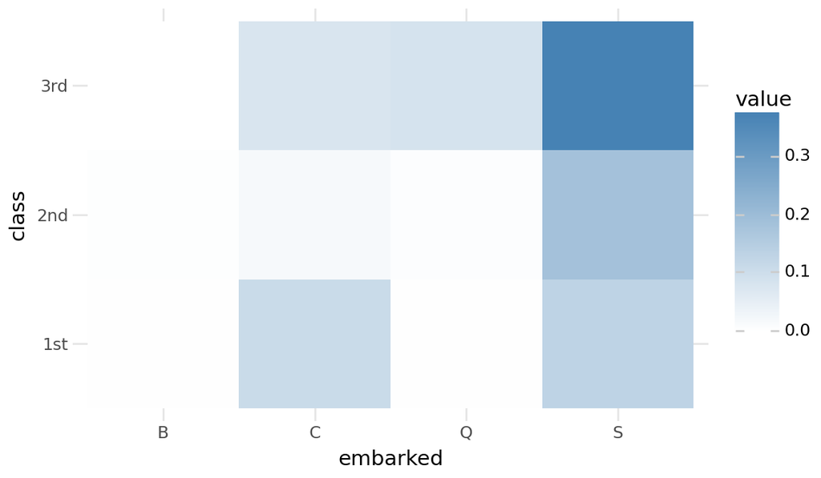

```python
heat_df = (ct.reset_index().melt(id_vars="class", var_name="embarked", value_name="value"))
heat_df

(ggplot(heat_df, aes(x="embarked", y="class", fill="value"))
    + geom_tile()
    + scale_fill_gradient(low="white", high="steelblue")
    + theme_minimal()
)
```

This visualization provides a good look at the total distribution, and you are able to see the class/embarked specific distributions.